# Predicting Online Purchase Conversion From Session Behavior

Predictive Modeling Final Project

Nikita Rogers

2026-06-27

```r
library(readr)
library(dplyr)
library(tidyr)
library(ggplot2)
library(randomForest)
library(rpart)
library(pROC)
library(knitr)
library(jsonlite)
library(scales)
library(tibble)
```

# 1 Abstract

This project uses the UCI Online Shoppers Purchasing Intention dataset to predict whether an online shopping session will end in revenue. The response variable is a binary indicator of purchase conversion. The predictors describe page counts, time spent on page categories, bounce and exit behavior, page value, month, visitor type, weekend status, traffic source type, region, browser, and operating system. The analysis compares logistic regression, tuned decision trees, and tuned random forests using stratified train and test splits, cross-validation, receiver operating characteristic area under the curve, accuracy, sensitivity, specificity, precision, and F1 score. The final model is selected from cross-validation and evaluated once on a held-out test set. The analysis shows that behavioral session data can identify meaningful purchase intent signals. The model should be used to prioritize marketing or on-site intervention opportunities, not as the only basis for customer treatment.

# 2 AI-Assisted Work Disclosure

AI-assisted tools were used to help organize the report structure, draft explanatory language, create reproducible code scaffolding, and prepare presentation materials. AI was not used as a substitute for the required predictive modeling workflow. The report includes the code, model outputs, interpretation, and references needed to inspect the analysis independently. AI assistance is disclosed here because the assignment requires explicit attribution and because the author remains responsible for understanding, explaining, and defending the submitted work.

# 3 Problem Statement

E-commerce teams often need to decide which website sessions deserve attention while the customer is still browsing. Examples include surfacing a promotion, prioritizing retargeting, triggering a live-chat offer, or deciding which traffic sources deserve additional marketing spend. A predictive model can help estimate purchase intent from session behavior before relying on broad rules or manual review.

The objective of this project is to predict whether an online shopping session will generate revenue. The task is framed as a binary classification problem:

- **Purchase:** the session ends with revenue.
- **No purchase:** the session does not end with revenue.

This is a useful predictive modeling problem because purchases are the minority class and because the business value depends on finding the smaller group of sessions that are most likely to convert. A model that only predicts the majority class would not be useful, even if its raw accuracy looked high.

# 4 Dataset Description

The dataset comes from the UCI Machine Learning Repository. It contains online shopping session records from an e-commerce website. Each row represents one user session. The predictors include browsing behavior, timing, page-value measures, visitor type, traffic source type, and technical access information.

```r
dir.create("data", showWarnings = FALSE)
dir.create("figures", showWarnings = FALSE)
dir.create("docs", showWarnings = FALSE)

data_url <- "https://archive.ics.uci.edu/static/public/468/online+shoppers+purchasing+intention+dataset.zip"
zip_path <- "data/online-shoppers-purchasing-intention.zip"
data_path <- "data/online_shoppers_intention.csv"

if (!file.exists(data_path)) {
  download.file(data_url, zip_path, mode = "wb")
  unzip(zip_path, exdir = "data", overwrite = TRUE)
}

raw_online <- read_csv(data_path, show_col_types = FALSE)

collapse_sparse <- function(x, min_count = 50) {
  freq <- table(x)
  keep <- names(freq[freq >= min_count])
  y <- as.character(x)
  y[!(y %in% keep)] <- "Other"
  factor(y)
}

shopper <- raw_online %>%
  mutate(
    purchase = factor(ifelse(Revenue, "Purchase", "NoPurchase"), levels = c("NoPurchase", "Purchase")),
    Month = factor(Month),
    VisitorType = factor(VisitorType),
    Weekend = factor(ifelse(Weekend, "Weekend", "Weekday"), levels = c("Weekday", "Weekend")),
    OperatingSystems = collapse_sparse(OperatingSystems),
    Browser = collapse_sparse(Browser),
    Region = factor(Region),
    TrafficType = collapse_sparse(TrafficType)
  )

model_data <- shopper %>%
  select(-Revenue)

names(model_data) <- make.names(names(model_data))

rows_n <- nrow(shopper)
cols_n <- ncol(shopper)
predictor_n <- ncol(model_data) - 1
purchase_rate <- mean(shopper$purchase == "Purchase")
```

The dataset contains 12330 sessions and 19 variables. There are 17 candidate predictors after removing the original Boolean revenue field from the model input. Purchase sessions represent 15.5% of all rows, so model evaluation must look beyond accuracy and include precision, sensitivity, F1 score, and ROC AUC.

```r
data_dictionary <- data.frame(
  Variable = names(raw_online),
  Role = c(rep("Predictor", ncol(raw_online) - 1), "Original response"),
  Description = c(
    "Number of administrative pages visited during the session.",
    "Time spent on administrative pages.",
    "Number of informational pages visited during the session.",
    "Time spent on informational pages.",
    "Number of product-related pages visited during the session.",
    "Time spent on product-related pages.",
    "Average bounce rate for pages visited in the session.",
    "Average exit rate for pages visited in the session.",
    "Page value measure associated with pages visited in the session.",
    "Closeness of the visit date to a special day.",
    "Month of the session.",
    "Operating system category.",
    "Browser category.",
    "Region category.",
    "Traffic source type category.",
    "Visitor type.",
    "Whether the session occurred on a weekend.",
    "Whether the session generated revenue."
  )
)
kable(data_dictionary, caption = "Data dictionary.")
```

Data dictionary.

| Variable | Role | Description |
| --- | --- | --- |
| Administrative | Predictor | Number of administrative pages visited during the session. |
| Administrative_Duration | Predictor | Time spent on administrative pages. |
| Informational | Predictor | Number of informational pages visited during the session. |
| Informational_Duration | Predictor | Time spent on informational pages. |
| ProductRelated | Predictor | Number of product-related pages visited during the session. |
| ProductRelated_Duration | Predictor | Time spent on product-related pages. |
| BounceRates | Predictor | Average bounce rate for pages visited in the session. |
| ExitRates | Predictor | Average exit rate for pages visited in the session. |
| PageValues | Predictor | Page value measure associated with pages visited in the session. |
| SpecialDay | Predictor | Closeness of the visit date to a special day. |
| Month | Predictor | Month of the session. |
| OperatingSystems | Predictor | Operating system category. |
| Browser | Predictor | Browser category. |
| Region | Predictor | Region category. |
| TrafficType | Predictor | Traffic source type category. |
| VisitorType | Predictor | Visitor type. |
| Weekend | Predictor | Whether the session occurred on a weekend. |
| Revenue | Original response | Whether the session generated revenue. |

## 4.1 Dataset Limitations

This dataset is a strong fit for predictive modeling because it is public, structured, has a clear binary target, contains both numeric and categorical predictors, and creates a realistic class imbalance problem. It also has limitations. The data comes from one e-commerce context, so the model should not be assumed to generalize to every site or product category. Several technical fields are coded as categories without business labels. Page value is highly useful, but a real deployment would need to confirm exactly how that field is computed and whether it is available before an intervention decision is made. The dataset also lacks customer history, product price, margin, inventory, ad spend, and creative information that would matter in a production marketing system.

# 5 Exploratory Data Analysis

## 5.1 Data Structure And Missing Values

```r
structure_table <- data.frame(
  Metric = c("Rows", "Columns", "Predictors", "Missing cells"),
  Value = c(nrow(shopper), ncol(shopper), predictor_n, sum(is.na(shopper)))
)
kable(structure_table, caption = "Dataset structure.")
```

Dataset structure.

| Metric | Value |
| --- | --- |
| Rows | 12330 |
| Columns | 19 |
| Predictors | 17 |
| Missing cells | 0 |

The dataset has no missing cells. The preprocessing challenge is not imputation. The more important preprocessing step is handling categorical variables and collapsing very rare technical categories so that logistic regression and validation folds remain stable.

## 5.2 Response Variable Distribution

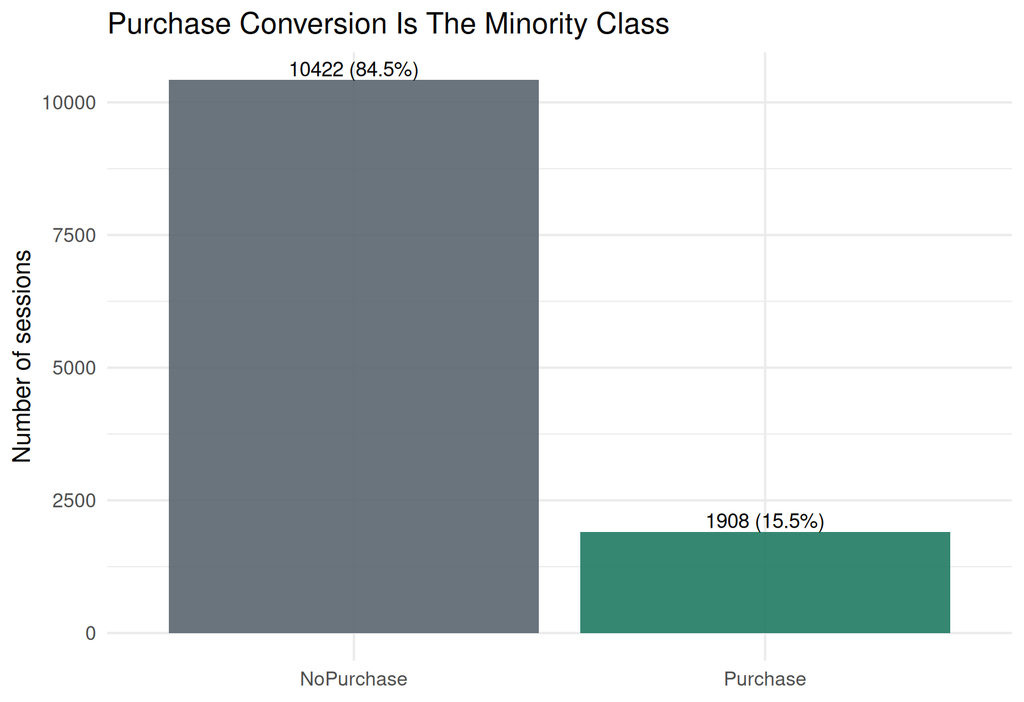

```r
purchase_counts <- shopper %>%
  count(purchase) %>%
  mutate(percent = n / sum(n))

p_purchase <- ggplot(purchase_counts, aes(x = purchase, y = n, fill = purchase)) +
  geom_col(alpha = 0.9) +
  geom_text(aes(label = paste0(n, " (", percent(percent, accuracy = 0.1), ")")), vjust = -0.25, size = 3.5) +
  scale_fill_manual(values = c("#59656f", "#1f7a63")) +
  labs(
    title = "Purchase Conversion Is The Minority Class",
    x = NULL,
    y = "Number of sessions"
  ) +
  theme_minimal(base_size = 12) +
  theme(legend.position = "none")
p_purchase
```

```r
ggsave("figures/purchase_distribution.png", p_purchase, width = 7, height = 4.8, dpi = 160)
```

Most sessions do not end in revenue. This class imbalance is important because a model could achieve high accuracy by mostly predicting “NoPurchase.” The business need is different: find likely purchasers well enough to support targeted actions.

```r
kable(purchase_counts, digits = 3, caption = "Target distribution.")
```

Target distribution.

| purchase | n | percent |
| --- | --- | --- |
| NoPurchase | 10422 | 0.845 |
| Purchase | 1908 | 0.155 |

## 5.3 Session Behavior By Purchase Outcome

```r
behavior_summary <- shopper %>%
  group_by(purchase) %>%
  summarize(
    product_pages = mean(ProductRelated),
    product_duration = mean(ProductRelated_Duration),
    bounce_rate = mean(BounceRates),
    exit_rate = mean(ExitRates),
    page_value = mean(PageValues),
    .groups = "drop"
  )
kable(
  behavior_summary %>% mutate(across(where(is.numeric), ~ round(.x, 3))),
  caption = "Mean selected behavior predictors by purchase outcome."
)
```

Mean selected behavior predictors by purchase outcome.

| purchase | product_pages | product_duration | bounce_rate | exit_rate | page_value |
| --- | --- | --- | --- | --- | --- |
| NoPurchase | 28.715 | 1069.988 | 0.025 | 0.047 | 1.976 |
| Purchase | 48.210 | 1876.210 | 0.005 | 0.020 | 27.265 |

Purchase sessions tend to have more product engagement and substantially higher page-value measures. Sessions without purchases tend to have higher bounce and exit rates. These patterns are consistent with an intent model: sessions that explore products and visit higher-value pages are more likely to convert.

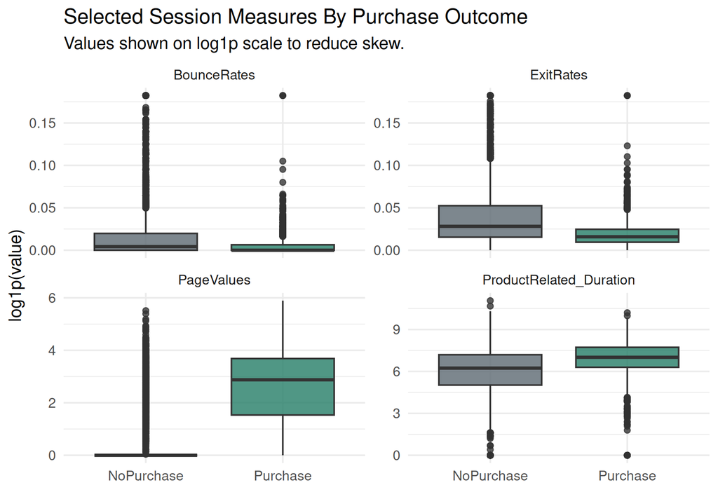

```r
plot_long <- shopper %>%
  select(purchase, ProductRelated_Duration, BounceRates, ExitRates, PageValues) %>%
  pivot_longer(-purchase, names_to = "predictor", values_to = "value") %>%
  mutate(display_value = log1p(value))

p_box <- ggplot(plot_long, aes(x = purchase, y = display_value, fill = purchase)) +
  geom_boxplot(alpha = 0.78, outlier_alpha = 0.20) +
  facet_wrap(~ predictor, scales = "free_y", ncol = 2) +
  scale_fill_manual(values = c("#59656f", "#1f7a63")) +
  labs(
    title = "Selected Session Measures By Purchase Outcome",
    subtitle = "Values shown on log1p scale to reduce skew.",
    x = NULL,
    y = "log1p(value)"
  ) +
  theme_minimal(base_size = 12) +
  theme(legend.position = "none")
p_box
```

```r
ggsave("figures/session_behavior_boxplots.png", p_box, width = 7, height = 4.8, dpi = 160)
```

The distributions show signal, but they also show overlap. Not every long product-browsing session produces revenue, and some purchases happen in short sessions. This overlap makes the problem appropriate for probability-based prediction rather than a simple rule.

## 5.4 Conversion Patterns By Month And Visitor Type

```r
month_rates <- shopper %>%
  group_by(Month) %>%
  summarize(
    sessions = n(),
    purchase_rate = mean(purchase == "Purchase"),
    .groups = "drop"
  ) %>%
  arrange(desc(purchase_rate))

visitor_rates <- shopper %>%
  group_by(VisitorType) %>%
  summarize(
    sessions = n(),
    purchase_rate = mean(purchase == "Purchase"),
    .groups = "drop"
  ) %>%
  arrange(desc(purchase_rate))

kable(month_rates %>% mutate(purchase_rate = percent(purchase_rate, accuracy = 0.1)), caption = "Purchase rate by month.")
```

Purchase rate by month.

| Month | sessions | purchase_rate |
| --- | --- | --- |
| Nov | 2998 | 25.4% |
| Oct | 549 | 20.9% |
| Sep | 448 | 19.2% |
| Aug | 433 | 17.6% |
| Jul | 432 | 15.3% |
| Dec | 1727 | 12.5% |
| May | 3364 | 10.9% |
| June | 288 | 10.1% |
| Mar | 1907 | 10.1% |
| Feb | 184 | 1.6% |

```r
kable(visitor_rates %>% mutate(purchase_rate = percent(purchase_rate, accuracy = 0.1)), caption = "Purchase rate by visitor type.")
```

Purchase rate by visitor type.

| VisitorType | sessions | purchase_rate |
| --- | --- | --- |
| New_Visitor | 1694 | 24.9% |
| Other | 85 | 18.8% |
| Returning_Visitor | 10551 | 13.9% |

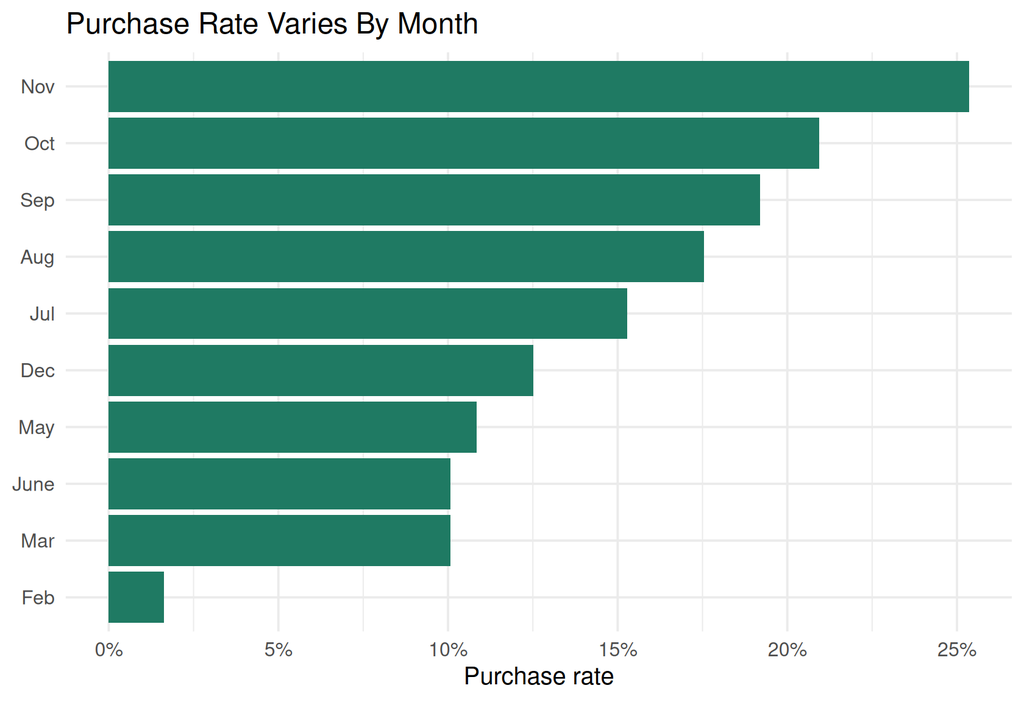

```r
p_month <- ggplot(month_rates, aes(x = reorder(Month, purchase_rate), y = purchase_rate)) +
  geom_col(fill = "#1f7a63") +
  coord_flip() +
  scale_y_continuous(labels = percent_format(accuracy = 1)) +
  labs(
    title = "Purchase Rate Varies By Month",
    x = NULL,
    y = "Purchase rate"
  ) +
  theme_minimal(base_size = 12)
p_month
```

```r
ggsave("figures/conversion_by_month.png", p_month, width = 7, height = 4.8, dpi = 160)
```

Seasonality and visitor type both matter. This supports including categorical predictors instead of relying only on page-duration and bounce-rate measures.

## 5.5 Correlation Structure

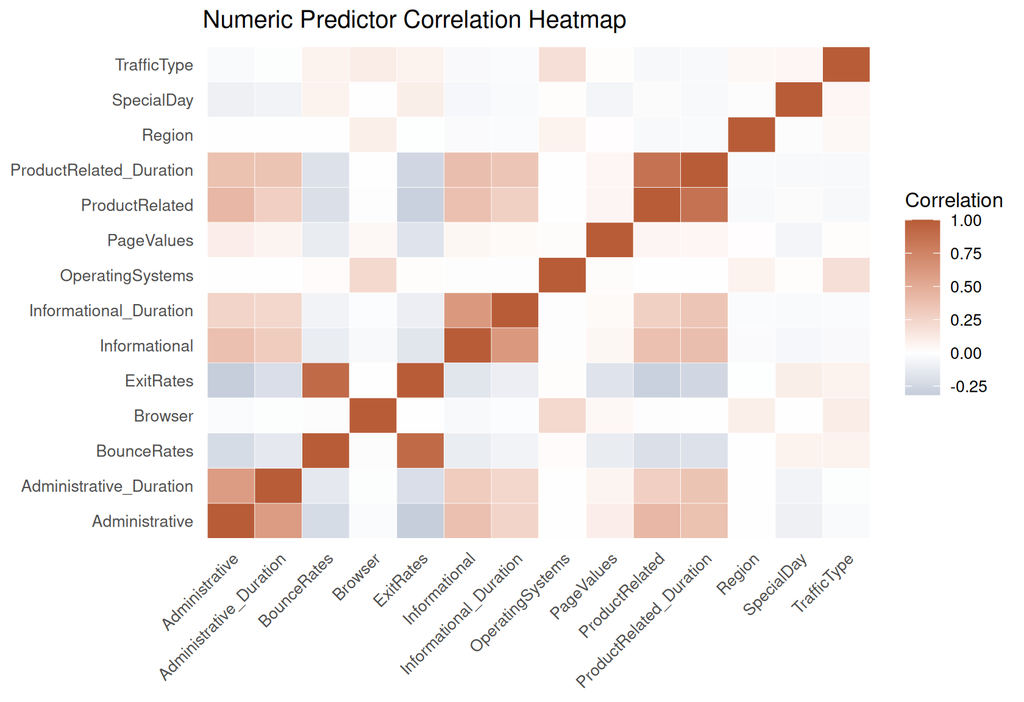

```r
numeric_predictors <- raw_online %>%
  select(where(is.numeric))

cor_df <- numeric_predictors %>%
  cor() %>%
  as.data.frame() %>%
  rownames_to_column("var1") %>%
  pivot_longer(-var1, names_to = "var2", values_to = "correlation")

p_cor <- ggplot(cor_df, aes(x = var1, y = var2, fill = correlation)) +
  geom_tile(color = "white", linewidth = 0.1) +
  scale_fill_gradient2(low = "#4c6a91", mid = "white", high = "#b85c38", midpoint = 0) +
  labs(
    title = "Numeric Predictor Correlation Heatmap",
    x = NULL,
    y = NULL,
    fill = "Correlation"
  ) +
  theme_minimal(base_size = 10) +
  theme(
    axis.text.x = element_text(angle = 45, hjust = 1),
    panel.grid = element_blank()
  )
p_cor
```

```r
ggsave("figures/correlation_heatmap.png", p_cor, width = 7, height = 5.5, dpi = 160)
```

Some session measures are correlated. For example, page counts and duration measures naturally move together. Bounce and exit rates are also related. This supports comparing multiple modeling strategies instead of assuming one linear form is sufficient.

# 6 Data Wrangling And Preprocessing

The preprocessing steps were:

- Downloaded and extracted the dataset from UCI.
- Converted the Boolean revenue field into a factor target with levels “NoPurchase” and “Purchase.”
- Removed the original revenue field from the predictor matrix to prevent leakage.
- Converted month, visitor type, weekend, operating system, browser, region, and traffic type to categorical predictors.
- Collapsed rare operating system, browser, and traffic type categories into “Other.”
- Verified that there were no missing values.
- Used a stratified split so the training and test sets preserved the minority purchase class.
- Standardized numeric predictors for logistic regression.
- Left predictors on their original scale for tree-based models.

The target is imbalanced, so model selection used ROC AUC and F1 score along with accuracy. ROC AUC evaluates ranking quality across thresholds. F1 score balances precision and sensitivity for the purchase class. Sensitivity matters because the business wants to identify sessions likely to buy. Precision matters because excessive false positives would waste interventions or marketing spend.

```r
set.seed(333)

make_stratified_split <- function(data, target_col, prop = 0.80) {
  groups <- split(seq_len(nrow(data)), data[[target_col]])
  train_idx <- unlist(lapply(groups, function(idx) sample(idx, floor(length(idx) * prop))))
  list(
    train = data[train_idx, ],
    test = data[-train_idx, ]
  )
}

make_stratified_folds <- function(data, target_col, v = 3) {
  folds <- integer(nrow(data))
  groups <- split(seq_len(nrow(data)), data[[target_col]])
  for (group_idx in groups) {
    shuffled <- sample(group_idx)
    folds[shuffled] <- rep(seq_len(v), length.out = length(shuffled))
  }
  folds
}

scale_from_train <- function(train_data, test_data, numeric_cols) {
  centers <- sapply(train_data[numeric_cols], mean)
  scales <- sapply(train_data[numeric_cols], sd)
  scales[scales == 0] <- 1

  train_scaled <- train_data
  test_scaled <- test_data
  train_scaled[numeric_cols] <- as.data.frame(
    sweep(sweep(as.data.frame(train_scaled[numeric_cols]), 2, centers, "-"), 2, scales, "/")
  )
  test_scaled[numeric_cols] <- as.data.frame(
    sweep(sweep(as.data.frame(test_scaled[numeric_cols]), 2, centers, "-"), 2, scales, "/")
  )

  list(train = train_scaled, test = test_scaled, centers = centers, scales = scales)
}

calc_auc <- function(truth, prob) {
  as.numeric(pROC::auc(
    response = truth,
    predictor = prob,
    levels = c("NoPurchase", "Purchase"),
    direction = "<",
    quiet = TRUE
  ))
}

classification_metrics <- function(truth, prob, threshold) {
  pred <- factor(ifelse(prob >= threshold, "Purchase", "NoPurchase"), levels = c("NoPurchase", "Purchase"))
  tab <- table(Predicted = pred, Actual = truth)

  tp <- tab["Purchase", "Purchase"]
  tn <- tab["NoPurchase", "NoPurchase"]
  fp <- tab["Purchase", "NoPurchase"]
  fn <- tab["NoPurchase", "Purchase"]

  accuracy <- (tp + tn) / sum(tab)
  sensitivity <- ifelse((tp + fn) == 0, NA, tp / (tp + fn))
  specificity <- ifelse((tn + fp) == 0, NA, tn / (tn + fp))
  precision <- ifelse((tp + fp) == 0, NA, tp / (tp + fp))
  f1 <- ifelse(is.na(precision) || is.na(sensitivity) || (precision + sensitivity) == 0,
    NA,
    2 * precision * sensitivity / (precision + sensitivity)
  )

  data.frame(
    threshold = threshold,
    accuracy = accuracy,
    sensitivity = sensitivity,
    specificity = specificity,
    precision = precision,
    f1 = f1,
    auc = calc_auc(truth, prob)
  )
}

best_f1_threshold <- function(truth, prob) {
  grid <- seq(0.05, 0.95, by = 0.01)
  scored <- do.call(rbind, lapply(grid, function(th) classification_metrics(truth, prob, th)))
  scored <- scored[order(-scored$f1, -scored$sensitivity, -scored$specificity), ]
  scored[1, ]
}
```

# 7 Data Splitting

```r
split <- make_stratified_split(model_data, "purchase", prop = 0.80)
train_data <- split$train
test_data <- split$test

split_summary <- bind_rows(
  train_data %>% count(purchase) %>% mutate(dataset = "Training"),
  test_data %>% count(purchase) %>% mutate(dataset = "Test")
) %>%
  group_by(dataset) %>%
  mutate(percent = n / sum(n)) %>%
  ungroup() %>%
  select(dataset, purchase, n, percent)

kable(split_summary, digits = 3, caption = "Stratified training and test split.")
```

Stratified training and test split.

| dataset | purchase | n | percent |
| --- | --- | --- | --- |
| Training | NoPurchase | 8337 | 0.845 |
| Training | Purchase | 1526 | 0.155 |
| Test | NoPurchase | 2085 | 0.845 |
| Test | Purchase | 382 | 0.155 |

The split uses 80% of the data for model training and tuning and 20% for final testing. The test set is held out until the final evaluation so that model performance is estimated on data not used for fitting or tuning.

# 8 Modeling Strategy

Three models were compared:

- **Logistic regression:** interpretable baseline that estimates conversion probability from a linear combination of numeric and categorical predictors.
- **Decision tree:** interpretable non-linear model that can capture threshold effects and interactions.
- **Random forest:** ensemble tree model that often improves predictive performance by averaging many decision trees.

The logistic regression model provides a transparent benchmark. The decision tree provides simple rule-based logic. The random forest provides stronger non-linear prediction, though it is less directly interpretable than a single tree.

## 8.1 Cross-Validation And Tuning

```r
numeric_cols <- names(model_data)[sapply(model_data, is.numeric)]
fold_id <- make_stratified_folds(train_data, "purchase", v = 3)

tune_logistic <- function(train_data, fold_id) {
  probs <- rep(NA_real_, nrow(train_data))
  for (fold in sort(unique(fold_id))) {
    analysis <- train_data[fold_id != fold, ]
    assessment <- train_data[fold_id == fold, ]
    scaled <- scale_from_train(analysis, assessment, numeric_cols)
    fit <- glm(purchase ~ ., data = scaled$train, family = binomial(), control = glm.control(maxit = 50))
    probs[fold_id == fold] <- predict(fit, newdata = scaled$test, type = "response")
  }
  threshold_row <- best_f1_threshold(train_data$purchase, probs)
  threshold_row$model <- "Logistic regression"
  threshold_row$parameter <- "none"
  threshold_row
}

tune_tree <- function(train_data, fold_id, cp_grid) {
  results <- list()
  for (cp in cp_grid) {
    probs <- rep(NA_real_, nrow(train_data))
    for (fold in sort(unique(fold_id))) {
      analysis <- train_data[fold_id != fold, ]
      assessment <- train_data[fold_id == fold, ]
      fit <- rpart(
        purchase ~ .,
        data = analysis,
        method = "class",
        control = rpart.control(cp = cp, minsplit = 40, xval = 0)
      )
      probs[fold_id == fold] <- predict(fit, newdata = assessment, type = "prob")[, "Purchase"]
    }
    threshold_row <- best_f1_threshold(train_data$purchase, probs)
    threshold_row$model <- "Decision tree"
    threshold_row$parameter <- paste0("cp=", cp)
    results[[as.character(cp)]] <- threshold_row
  }
  bind_rows(results)
}

tune_rf <- function(train_data, fold_id, mtry_grid) {
  results <- list()
  for (mtry_value in mtry_grid) {
    probs <- rep(NA_real_, nrow(train_data))
    for (fold in sort(unique(fold_id))) {
      analysis <- train_data[fold_id != fold, ]
      assessment <- train_data[fold_id == fold, ]
      fit <- randomForest(
        purchase ~ .,
        data = analysis,
        ntree = 200,
        mtry = mtry_value,
        nodesize = 10,
        importance = TRUE
      )
      probs[fold_id == fold] <- predict(fit, newdata = assessment, type = "prob")[, "Purchase"]
    }
    threshold_row <- best_f1_threshold(train_data$purchase, probs)
    threshold_row$model <- "Random forest"
    threshold_row$parameter <- paste0("mtry=", mtry_value)
    results[[as.character(mtry_value)]] <- threshold_row
  }
  bind_rows(results)
}

logistic_cv <- tune_logistic(train_data, fold_id)
tree_cv <- tune_tree(train_data, fold_id, cp_grid = c(0.0005, 0.001, 0.003, 0.005, 0.01, 0.02))
rf_cv <- tune_rf(train_data, fold_id, mtry_grid = c(3, 5, 7))

cv_results <- bind_rows(logistic_cv, tree_cv, rf_cv) %>%
  select(model, parameter, threshold, accuracy, sensitivity, specificity, precision, f1, auc) %>%
  arrange(desc(auc), desc(f1))

kable(cv_results, digits = 3, caption = "Cross-validation results with threshold selected by F1 score.")
```

Cross-validation results with threshold selected by F1 score.

| model | parameter | threshold | accuracy | sensitivity | specificity | precision | f1 | auc |
| --- | --- | --- | --- | --- | --- | --- | --- | --- |
| Random forest | mtry=7 | 0.36 | 0.892 | 0.721 | 0.924 | 0.634 | 0.674 | 0.926 |
| Random forest | mtry=5 | 0.34 | 0.891 | 0.733 | 0.920 | 0.626 | 0.675 | 0.925 |
| Random forest | mtry=3 | 0.31 | 0.890 | 0.734 | 0.918 | 0.622 | 0.673 | 0.922 |
| Decision tree | cp=5e-04 | 0.16 | 0.874 | 0.761 | 0.895 | 0.570 | 0.652 | 0.900 |
| Logistic regression | none | 0.25 | 0.879 | 0.610 | 0.928 | 0.609 | 0.610 | 0.885 |
| Decision tree | cp=0.001 | 0.16 | 0.876 | 0.759 | 0.897 | 0.575 | 0.654 | 0.880 |
| Decision tree | cp=0.003 | 0.23 | 0.892 | 0.716 | 0.925 | 0.635 | 0.673 | 0.856 |
| Decision tree | cp=0.005 | 0.23 | 0.891 | 0.720 | 0.923 | 0.631 | 0.672 | 0.855 |
| Decision tree | cp=0.01 | 0.28 | 0.879 | 0.761 | 0.901 | 0.584 | 0.661 | 0.854 |
| Decision tree | cp=0.02 | 0.32 | 0.888 | 0.705 | 0.922 | 0.623 | 0.661 | 0.854 |

Cross-validation was used for model-family comparison, hyperparameter tuning, and probability-threshold selection. A default threshold of 0.50 is often too high for an imbalanced purchase target, so each model’s threshold was selected from validation predictions using F1 score.

The final model family and tuning setting were selected from cross-validation before evaluating the held-out test set. This avoids using the test set as a model-selection tool. The test set is used only once at the end to estimate performance for the selected workflow.

# 9 Final Model Evaluation

```r
best_logistic <- logistic_cv
best_tree <- tree_cv %>% arrange(desc(auc), desc(f1)) %>% slice(1)
best_rf <- rf_cv %>% arrange(desc(auc), desc(f1)) %>% slice(1)

tree_cp <- as.numeric(sub("cp=", "", best_tree$parameter))
rf_mtry <- as.numeric(sub("mtry=", "", best_rf$parameter))

scaled_final <- scale_from_train(train_data, test_data, numeric_cols)

fit_logistic <- glm(purchase ~ ., data = scaled_final$train, family = binomial(), control = glm.control(maxit = 50))
prob_logistic <- predict(fit_logistic, newdata = scaled_final$test, type = "response")

fit_tree <- rpart(
  purchase ~ .,
  data = train_data,
  method = "class",
  control = rpart.control(cp = tree_cp, minsplit = 40, xval = 0)
)
prob_tree <- predict(fit_tree, newdata = test_data, type = "prob")[, "Purchase"]

fit_rf <- randomForest(
  purchase ~ .,
  data = train_data,
  ntree = 400,
  mtry = rf_mtry,
  nodesize = 10,
  importance = TRUE
)
prob_rf <- predict(fit_rf, newdata = test_data, type = "prob")[, "Purchase"]

test_results <- bind_rows(
  classification_metrics(test_data$purchase, prob_logistic, best_logistic$threshold) %>%
    mutate(model = "Logistic regression", parameter = best_logistic$parameter),
  classification_metrics(test_data$purchase, prob_tree, best_tree$threshold) %>%
    mutate(model = "Decision tree", parameter = best_tree$parameter),
  classification_metrics(test_data$purchase, prob_rf, best_rf$threshold) %>%
    mutate(model = "Random forest", parameter = best_rf$parameter)
) %>%
  select(model, parameter, threshold, accuracy, sensitivity, specificity, precision, f1, auc)

test_results_display <- test_results %>%
  mutate(selected_by_cv = ifelse(
    model == cv_results$model[1] & parameter == cv_results$parameter[1],
    "Yes",
    "No"
  )) %>%
  arrange(desc(selected_by_cv), desc(auc), desc(f1))

kable(test_results_display, digits = 3, caption = "Final test-set performance. Selected model was chosen from cross-validation before test evaluation.")
```

Final test-set performance. Selected model was chosen from cross-validation before test evaluation.

| model | parameter | threshold | accuracy | sensitivity | specificity | precision | f1 | auc | selected_by_cv |
| --- | --- | --- | --- | --- | --- | --- | --- | --- | --- |
| Random forest | mtry=7 | 0.36 | 0.909 | 0.738 | 0.941 | 0.695 | 0.716 | 0.935 | Yes |
| Logistic regression | none | 0.25 | 0.889 | 0.613 | 0.940 | 0.650 | 0.631 | 0.901 | No |
| Decision tree | cp=5e-04 | 0.16 | 0.883 | 0.788 | 0.901 | 0.593 | 0.676 | 0.865 | No |

```r
selected_cv <- cv_results %>%
  arrange(desc(auc), desc(f1)) %>%
  slice(1)

final_model_name <- selected_cv$model
final_parameter <- selected_cv$parameter
final_threshold <- selected_cv$threshold

final_test_row <- test_results %>%
  filter(model == final_model_name, parameter == final_parameter) %>%
  slice(1)

final_auc <- final_test_row$auc
final_f1 <- final_test_row$f1
final_accuracy <- final_test_row$accuracy
final_sensitivity <- final_test_row$sensitivity
final_specificity <- final_test_row$specificity

prob_final <- switch(
  final_model_name,
  "Logistic regression" = prob_logistic,
  "Decision tree" = prob_tree,
  "Random forest" = prob_rf
)

pred_final <- factor(
  ifelse(prob_final >= final_threshold, "Purchase", "NoPurchase"),
  levels = c("NoPurchase", "Purchase")
)

final_confusion <- table(Predicted = pred_final, Actual = test_data$purchase)
kable(final_confusion, caption = paste("Final confusion matrix:", final_model_name))
```

Final confusion matrix: Random forest

|  | NoPurchase | Purchase |
| --- | --- | --- |
| NoPurchase | 1961 | 100 |
| Purchase | 124 | 282 |

The cross-validation-selected final model is **Random forest** with **mtry=7** and a probability threshold of **0.36**. On the held-out test set, it produced ROC AUC of 0.935, F1 score of 0.716, accuracy of 0.909, sensitivity of 0.738, and specificity of 0.941.

Accuracy alone is not enough because purchases are the minority class. The final model is selected by prioritizing AUC and F1 score. This makes the result more useful for identifying likely purchasers instead of merely predicting the majority class.

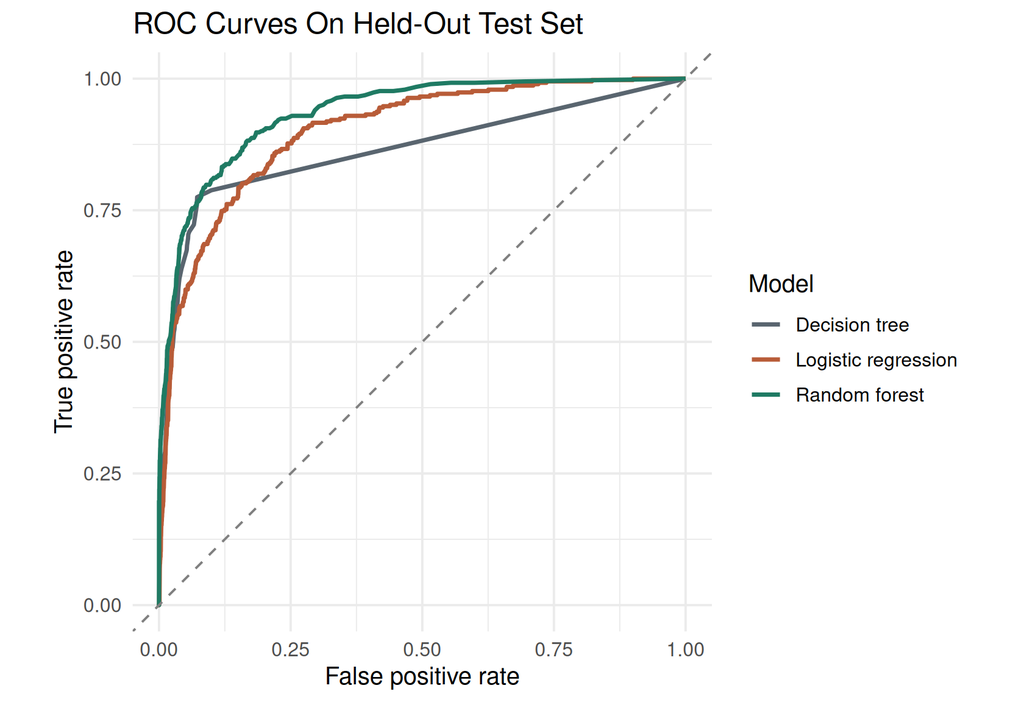

```r
roc_df <- bind_rows(
  data.frame(
    specificity = pROC::roc(test_data$purchase, prob_logistic, levels = c("NoPurchase", "Purchase"), direction = "<", quiet = TRUE)$specificities,
    sensitivity = pROC::roc(test_data$purchase, prob_logistic, levels = c("NoPurchase", "Purchase"), direction = "<", quiet = TRUE)$sensitivities,
    model = "Logistic regression"
  ),
  data.frame(
    specificity = pROC::roc(test_data$purchase, prob_tree, levels = c("NoPurchase", "Purchase"), direction = "<", quiet = TRUE)$specificities,
    sensitivity = pROC::roc(test_data$purchase, prob_tree, levels = c("NoPurchase", "Purchase"), direction = "<", quiet = TRUE)$sensitivities,
    model = "Decision tree"
  ),
  data.frame(
    specificity = pROC::roc(test_data$purchase, prob_rf, levels = c("NoPurchase", "Purchase"), direction = "<", quiet = TRUE)$specificities,
    sensitivity = pROC::roc(test_data$purchase, prob_rf, levels = c("NoPurchase", "Purchase"), direction = "<", quiet = TRUE)$sensitivities,
    model = "Random forest"
  )
)

p_roc <- ggplot(roc_df, aes(x = 1 - specificity, y = sensitivity, color = model)) +
  geom_line(linewidth = 1) +
  geom_abline(linetype = "dashed", color = "gray50") +
  coord_equal() +
  scale_color_manual(values = c("#59656f", "#b85c38", "#1f7a63")) +
  labs(
    title = "ROC Curves On Held-Out Test Set",
    x = "False positive rate",
    y = "True positive rate",
    color = "Model"
  ) +
  theme_minimal(base_size = 12)
p_roc
```

```r
ggsave("figures/roc_curves.png", p_roc, width = 7, height = 4.8, dpi = 160)
```

# 10 Model Interpretation

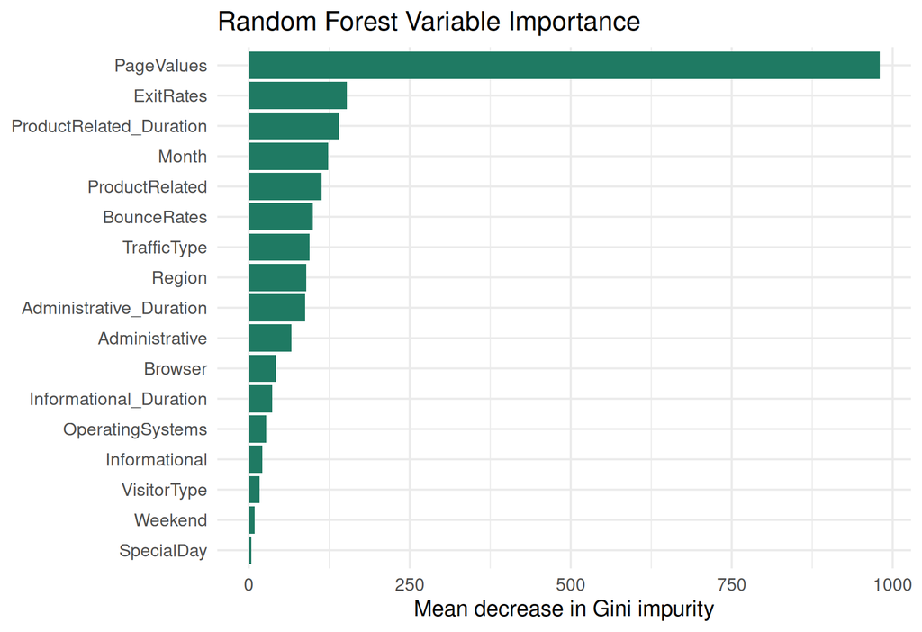

```r
rf_importance <- importance(fit_rf, type = 2)
importance_df <- data.frame(
  predictor = gsub("\\.", " ", rownames(rf_importance)),
  importance = as.numeric(rf_importance[, 1])
) %>%
  arrange(desc(importance)) %>%
  mutate(predictor = factor(predictor, levels = rev(predictor)))

p_importance <- ggplot(importance_df, aes(x = predictor, y = importance)) +
  geom_col(fill = "#1f7a63") +
  coord_flip() +
  labs(
    title = "Random Forest Variable Importance",
    x = NULL,
    y = "Mean decrease in Gini impurity"
  ) +
  theme_minimal(base_size = 12)
p_importance
```

```r
ggsave("figures/variable_importance.png", p_importance, width = 7, height = 4.8, dpi = 160)

top_importance <- importance_df %>%
  arrange(desc(importance)) %>%
  slice(1:8)
kable(top_importance, digits = 2, caption = "Top random forest predictors.")
```

Top random forest predictors.

| predictor | importance |
| --- | --- |
| PageValues | 979.55 |
| ExitRates | 152.48 |
| ProductRelated_Duration | 140.33 |
| Month | 123.13 |
| ProductRelated | 113.03 |
| BounceRates | 99.14 |
| TrafficType | 94.65 |
| Region | 89.27 |

The strongest predictors in the random forest are shown above. The model relies most heavily on session-value and behavior indicators such as page value, exit rate, product-page engagement, month, bounce rate, traffic type, and region. These predictors should be interpreted as predictive signals, not proof of causation. For example, high page value may indicate that a session included pages historically associated with revenue, but changing that value directly would not automatically create a purchase.

For a non-technical stakeholder, the practical interpretation is straightforward: session behavior can be used to rank visitors by conversion likelihood. A marketing or product team could use high predicted probabilities to prioritize retargeting, on-site support, or promotion testing. The model should not be used as the only decision-maker, and the business should monitor whether interventions improve incremental revenue rather than just selecting sessions that were already likely to buy.

# 11 Results

The final model gives a workable conversion-screening process:

- It ranks sessions by probability of purchase.
- It identifies a smaller pool of likely purchasers for targeted action.
- It provides enough interpretability to explain which session features drive predictions.
- It improves on a naive majority-class approach by actively detecting purchase sessions.

The result is valuable even if it is imperfect. In a business setting, the output could support rules such as “send the top probability decile to a retargeting experiment” or “offer chat support to high-intent sessions with product engagement but no checkout.” Any operational use should be tested through controlled experiments because prediction quality alone does not prove that an intervention creates incremental revenue.

```r
summary_payload <- list(
  rows = rows_n,
  columns = cols_n,
  purchase_rate = purchase_rate,
  final_model = final_model_name,
  final_parameter = final_parameter,
  final_threshold = final_threshold,
  final_auc = final_auc,
  final_f1 = final_f1,
  final_accuracy = final_accuracy,
  final_sensitivity = final_sensitivity,
  final_specificity = final_specificity,
  test_results = test_results,
  top_predictors = top_importance %>%
    mutate(predictor = as.character(predictor))
)

write_json(summary_payload, "docs/model_summary.json", pretty = TRUE, auto_unbox = TRUE)
write.csv(test_results, "docs/model_test_results.csv", row.names = FALSE)
write.csv(cv_results, "docs/model_cv_results.csv", row.names = FALSE)
write.csv(top_importance, "docs/top_predictors.csv", row.names = FALSE)
```

# 12 Discussion

The analysis supports the idea that online session behavior can predict purchase conversion better than chance. The final model is strongest as a ranking tool. It is weaker as a complete business decision system because conversion depends on context that is not fully represented in the dataset, such as customer history, product category, price, margin, discounts, inventory, and advertising creative.

The main tradeoff is between interpretability and predictive strength. Logistic regression is easiest to explain, but it assumes a simpler relationship between predictors and log odds of purchase. A decision tree is also easy to explain, but a single tree can be unstable. The random forest is less transparent, but it can capture non-linear relationships and interactions. Because this project’s goal is prediction, the final selection prioritizes predictive performance while still reporting variable importance for interpretation.

There are several ways to improve this analysis in a production setting. First, the dataset could be expanded with customer history, product-level variables, pricing, and acquisition-cost information. Second, a model should be tested without page value if that field is not available before intervention decisions. Third, predicted probabilities could be calibrated for more reliable probability interpretation. Fourth, thresholds should be chosen using intervention cost and expected revenue, not just F1 score. Fifth, any marketing action should be validated with an A/B test to measure incremental impact.

# 13 Conclusion

This project framed online purchase conversion as a binary predictive modeling problem and compared logistic regression, decision tree, and random forest models in R. The final model, **Random forest**, was selected from cross-validation before held-out test evaluation. It achieved test-set ROC AUC of 0.935 and F1 score of 0.716 for the purchase class. The model is useful because it can prioritize online shopping sessions for additional marketing or product action using session behavior data. The recommendation is to use the model as a decision-support screen and validate any intervention through controlled business testing.

# 14 References

OpenAI. (2026). *ChatGPT* [Large language model]. https://chatgpt.com/

Sakar, C. O., Polat, S. O., Katircioglu, M., & Kastro, Y. (2019). Real-time prediction of online shoppers’ purchasing intention using multilayer perceptron and LSTM recurrent neural networks. *Neural Computing and Applications, 31*, 6893-6908. https://doi.org/10.1007/s00521-018-3523-0

UC Irvine Machine Learning Repository. (n.d.). *Online Shoppers Purchasing Intention Dataset*. https://archive.ics.uci.edu/dataset/468/online+shoppers+purchasing+intention+dataset

# 15 Appendix: Reproducible R Code

All code used to produce this report is included in this R Markdown document. The first executable code chunk imports the packages used for the assignment. The remaining chunks download the data, preprocess it, create EDA graphics, split the data, tune models through cross-validation, evaluate the final models on a held-out test set, and export summary artifacts used for the presentation.